# Mini-project 3 Template

Author

Grace Rubio, Oyinda Sanni, Mia Mason

Feel free to change render format to html using

format: html

self-contained: true

## Instructions

This is the template document for mini-project 3. You must use the template document for your code, since it will make it much easier to follow.

## Libraries and data load

Put whatever libraries you use here.

Load your data here

```r
# Full Dataset
FullData_2025 <- read.csv("Data/FullData_2025.csv")
```

```r
# Clean Data [Helpful for graphs and Models]
FullData_2025 <- FullData_2025|>
  drop_na()

# Establish Factors
FullData_2025<-FullData_2025|>
  mutate(Democracy=as.factor(Democracy), UN_member=as.factor(UN_member), world_4region=as.factor(world_4region))

head(FullData_2025)
```

```
  geo        name Democracy LifeExp     CO2        GDP   HDI  Poverty Internet
1 afg Afghanistan        No   69.02  11.694  2092.5459 0.496 20826260 16.09500
2 alb     Albania       Yes   80.00   5.976 20361.7928 0.810     3288 85.86390
3 arm     Armenia        No   79.92   7.507 21539.0115 0.811    50696 81.33930
4 aus   Australia       Yes   84.20 364.789 61942.6148 0.958   205448 96.13140
5 aut     Austria       Yes   82.20  82.244 64665.0188 0.930    48627 94.91975
6 bdi     Burundi        No   62.09   0.658   848.3745 0.439 10365398  8.59600
  Traffic_Deaths Sanitation UN_member world_4region
1          21.65   54.49580    Member          asia
2           5.85   99.29972    Member        europe
3           9.43   93.66494    Member        europe
4           4.43  100.00000    Member          asia
5           3.76   99.97210    Member        europe
6          61.23   44.63399    Member        africa
```

**NOTE REGARDING DATA:** Please note that the data for each variable was collected from the last year provided in their respective datasets. For our purposes, we will be treated all variables as being collected from the year 2025 regardless of their most recent data. Below are the *actual* years each column was collected from:

*Democracy:* 2020

*CO2 Emissions:* 2022

*GDP per Capita:* 2025

*Human Development Index:* 2023

*People in Poverty:* 2025

*Gapminder Regions:* 2025

*Life Expectancy at Birth:* 2025

*Number of Traffic Deaths Per 100k People:* 2023

*Number of Internet Users:* 2024

*UN Membership:* 2022

*Basic Sanitation Overall:* 2024

## Exploratory data analysis

For this section graph and find statistics for each of your 5 new predictor variables vs the response. You do not need to look at the predictor variables individually, although you can if you are considering logging.

## Variable 1: Democracy

### Graph and description

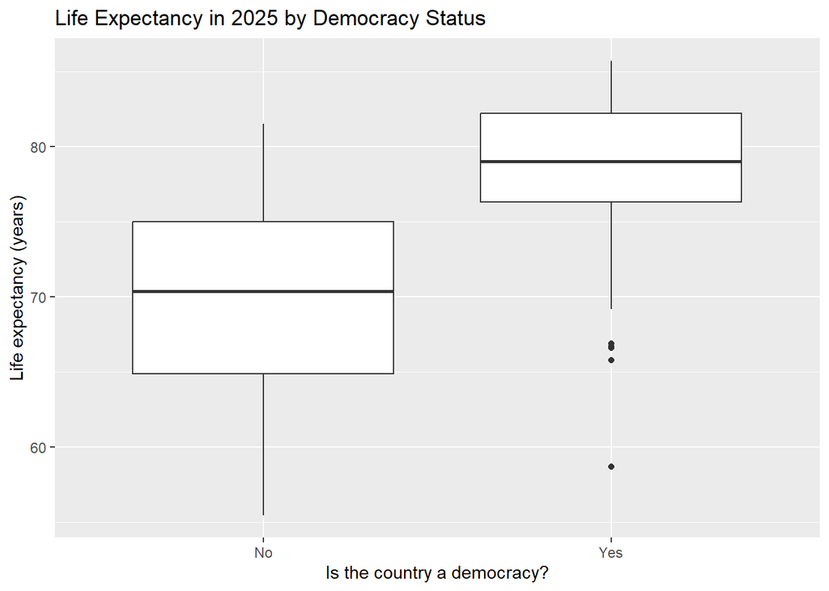

```r
#PLOT
FullData_2025 |>
  ggplot(aes(x = Democracy, y = LifeExp)) +
  geom_boxplot() +
  labs(x = "Is the country a democracy?",
       y = "Life expectancy (years)",
       title = "Life Expectancy in 2025 by Democracy Status")
```

From the boxplot, we can see that democracies tend to live longer than non-democracies. The median life expectancy is about 79 years for democracies and about 70 years for non-democracies. That is a gap of roughly 9 years. The middle halves of the two groups dont overlap. Non-democracies are more spread out, from about 55 to 81 years. Four democracies are outliers, with life expectancy of about 59 to 67 years.Democracy status looks like a useful predictor, but it does not directly prove that democracy causes longer life.Non-democracies are more spread out. Four democracies are low outliers: Lesotho, Ghana, Papua New Guinea, and Namibia.

### Stats and description

```r
Democracy_LifeExp_summary <- FullData_2025 |>
  group_by(Democracy) |>
  summarize(avg_lifeexp = mean(LifeExp),
            sd_lifeexp = sd(LifeExp),
            min_lifeexp = min(LifeExp),
            max_lifeexp = max(LifeExp),
            mdn_lifeexp = median(LifeExp),
            iqr_lifeexp = IQR(LifeExp),
            count = n())

Democracy_LifeExp_summary
```

```
# A tibble: 2 × 8
  Democracy avg_lifeexp sd_lifeexp min_lifeexp max_lifeexp mdn_lifeexp
  <fct>           <dbl>      <dbl>       <dbl>       <dbl>       <dbl>
1 No               69.9       6.31        55.5        81.5        70.4
2 Yes              78.2       5.36        58.7        85.7        79
# ℹ 2 more variables: iqr_lifeexp <dbl>, count <int>
```

```r
FullData_2025 |>
  filter(Democracy == "Yes") |>
  slice_min(LifeExp, n = 4) |>
  select(name, LifeExp)
```

```
              name LifeExp
1          Lesotho   58.71
2            Ghana   65.80
3 Papua New Guinea   66.60
4          Namibia   66.70
```

Democracies have a higher mean life expectancy than non-democracies, at 78.22 and 69.89 years. The medians are 79.00 and 70.39 years. Non-democracies vary more, with an SD of 6.31 and an IQR of 10.1, compared to 5.36 and 5.9 for democracies. The groups are about the same size, with 71 non-democracies and 69 democracies. The lowest democracy is Lesotho, at 58.71 years. Democracy looks like a strong predictor, because the gap is bigger than the spread within each group.

## Variable 2: *Number of Traffic Deaths Per 100k People*

### Graph and description

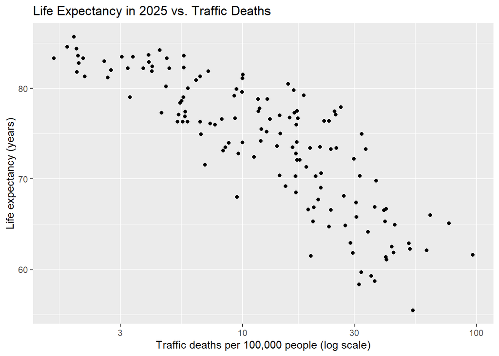

```r
FullData_2025 |>
  ggplot(aes(x = Traffic_Deaths, y = LifeExp)) +
  geom_point() +
  scale_x_log10() +
  labs(x = "Traffic deaths per 100,000 people (log scale)",
       y = "Life expectancy (years)",
       title = "Life Expectancy in 2025 vs. Traffic Deaths")
```

Countries with more traffic deaths tend to have lower life expectancy. The pattern is negative and slightly curved. Most countries have fewer than 40 deaths per 100,000 people. The points spread out more on the right side. Three countries are far to the right, at about 64, 76, and 96 deaths.Three countries are far to the right: Congo, Dem. Rep., Rwanda, and Uganda.

### Stats and description

```r
TrafficDeaths_summary <- FullData_2025 |>
  summarize(avg_td = mean(Traffic_Deaths),
            sd_td = sd(Traffic_Deaths),
            min_td = min(Traffic_Deaths),
            max_td = max(Traffic_Deaths),
            mdn_td = median(Traffic_Deaths),
            iqr_td = IQR(Traffic_Deaths),
            count = n())

TrafficDeaths_summary
```

```
    avg_td    sd_td min_td max_td mdn_td  iqr_td count
1 18.13329 16.03078   1.56   96.3   14.4 19.1175   140
```

```r
FullData_2025 |>
  summarize(r = cor(Traffic_Deaths, LifeExp),
            r_log = cor(log10(Traffic_Deaths), LifeExp))
```

```
           r      r_log
1 -0.7845197 -0.8326547
```

```r
FullData_2025 |>
  slice_max(Traffic_Deaths, n = 3) |>
  select(name, Traffic_Deaths, LifeExp)
```

```
              name Traffic_Deaths LifeExp
1 Congo, Dem. Rep.          96.30   61.60
2           Rwanda          76.42   65.08
3           Uganda          63.70   65.98
```

Traffic deaths range from 1.56 to 96.3 per 100,000 people across 140 countries. The mean is 18.13 and the median is 14.40, so a few high values pull the mean up. The SD is 16.03 and the IQR is 19.12. The correlation with life expectancy is -0.78, which is a strong negative relationship. The highest rates are in Congo, Dem. Rep. (96.30), Rwanda (76.42), and Uganda (63.70). I will log this variable, because the correlation improves to -0.83 after logging.

## Variable 3: *Number of Internet Users*

### Graph and description

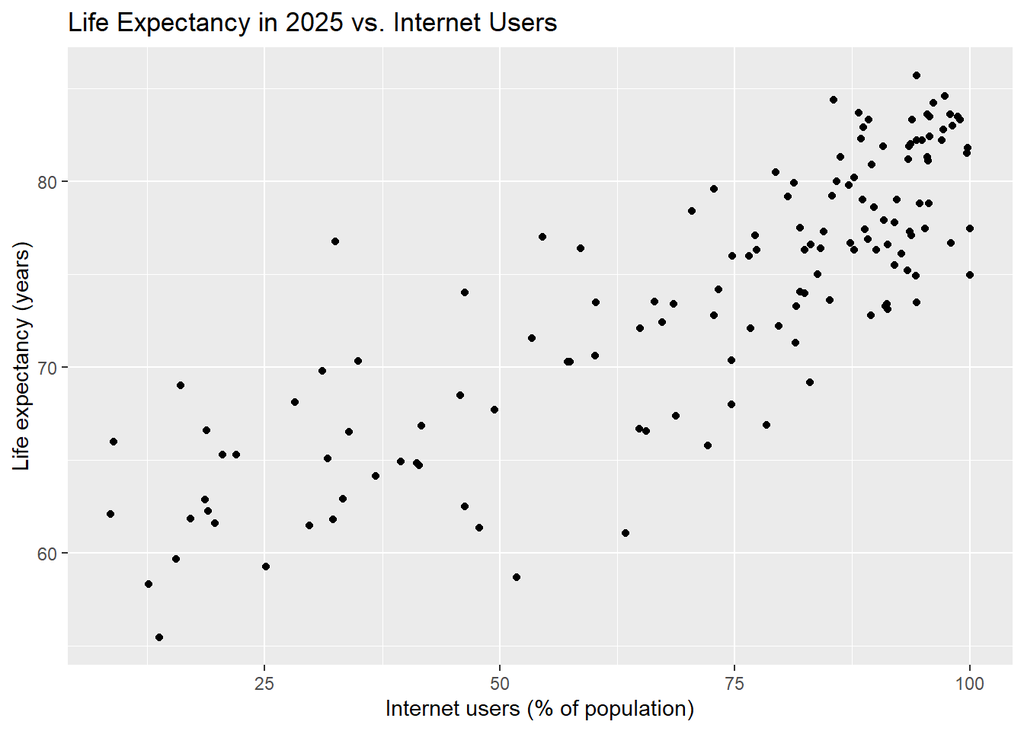

```r
FullData_2025 |>
  ggplot(aes(x = Internet, y = LifeExp)) +
  geom_point() +
  labs(x = "Internet users (% of population)",
       y = "Life expectancy (years)",
       title = "Life Expectancy in 2025 vs. Internet Users")
```

Countries with more internet use tend to have higher life expectancy. The pattern is positive. Most countries are near 100 percent online, and they bunch together at the top right. Countries with low internet use are more spread out, with life expectancy from about 55 to 77 years.

### Stats and description

```r
Internet_summary <- FullData_2025 |>
  summarize(avg_int = mean(Internet),
            sd_int = sd(Internet),
            min_int = min(Internet),
            max_int = max(Internet),
            mdn_int = median(Internet),
            iqr_int = IQR(Internet),
            count = n())

Internet_summary
```

```
   avg_int   sd_int min_int max_int  mdn_int  iqr_int count
1 71.36391 26.49307   8.596     100 82.19801 37.78301   140
```

```r
FullData_2025 |>
  summarize(r = cor(Internet, LifeExp),
            r_log = cor(log10(Internet), LifeExp))
```

```
          r     r_log
1 0.8345894 0.7793948
```

```r
FullData_2025 |>
  slice_min(Internet, n = 3) |>
  select(name, Internet, LifeExp)
```

```
     name Internet LifeExp
1 Burundi  8.59600   62.09
2  Uganda  8.94983   65.98
3    Chad 12.62690   58.32
```

Internet use ranges from 8.60 to 100 percent across 140 countries. The mean is 71.36 and the median is 82.20. The mean is lower than the median, so a few low countries pull it down. The SD is 26.49 and the IQR is 37.78, so the countries vary a lot.The lowest values are in Burundi (8.60), Uganda (8.95), and Chad (12.63). I will not log this variable, because the correlation is stronger on the original scale (0.83 vs. 0.78).

## Variable 4: *UN Membership*

### Graph and description

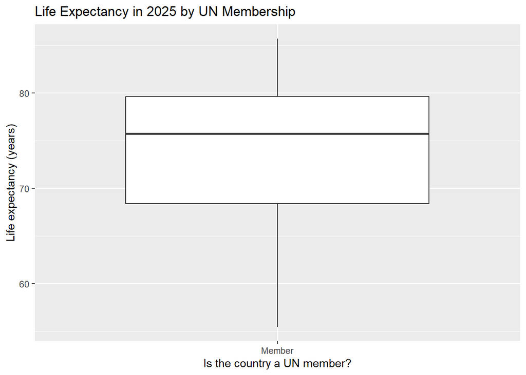

```r
FullData_2025 |>
  ggplot(aes(x = UN_member, y = LifeExp)) +
  geom_boxplot() +
  labs(x = "Is the country a UN member?",
       y = "Life expectancy (years)",
       title = "Life Expectancy in 2025 by UN Membership")
```

The plot shows only one group, because all 140 countries are UN members. The box covers life expectancy from about 68 to 80 years, with a median near 76. There is no second group to compare. This graph cannot show whether membership is linked to life expectancy.

### Stats and description

```r
UN_LifeExp_summary <- FullData_2025 |>
  group_by(UN_member) |>
  summarize(avg_lifeexp = mean(LifeExp),
            sd_lifeexp = sd(LifeExp),
            min_lifeexp = min(LifeExp),
            max_lifeexp = max(LifeExp),
            mdn_lifeexp = median(LifeExp),
            iqr_lifeexp = IQR(LifeExp),
            count = n())

UN_LifeExp_summary
```

```
# A tibble: 1 × 8
  UN_member avg_lifeexp sd_lifeexp min_lifeexp max_lifeexp mdn_lifeexp
  <fct>           <dbl>      <dbl>       <dbl>       <dbl>       <dbl>
1 Member           74.0       7.18        55.5        85.7        75.8
# ℹ 2 more variables: iqr_lifeexp <dbl>, count <int>
```

All 140 countries are UN members, so the table has only one row. Their mean life expectancy is 74.00 years and the median is 75.76 years. The SD is 7.18 and the IQR is 11.24. Life expectancy ranges from 55.48 to 85.71 years. With no non-members in the data, there is no variation in this predictor. It is a constant, so it is not useful for modeling. I will not use UN membership as a predictor

## Variable 5: *Basic Sanitation Overall*

### Graph and description

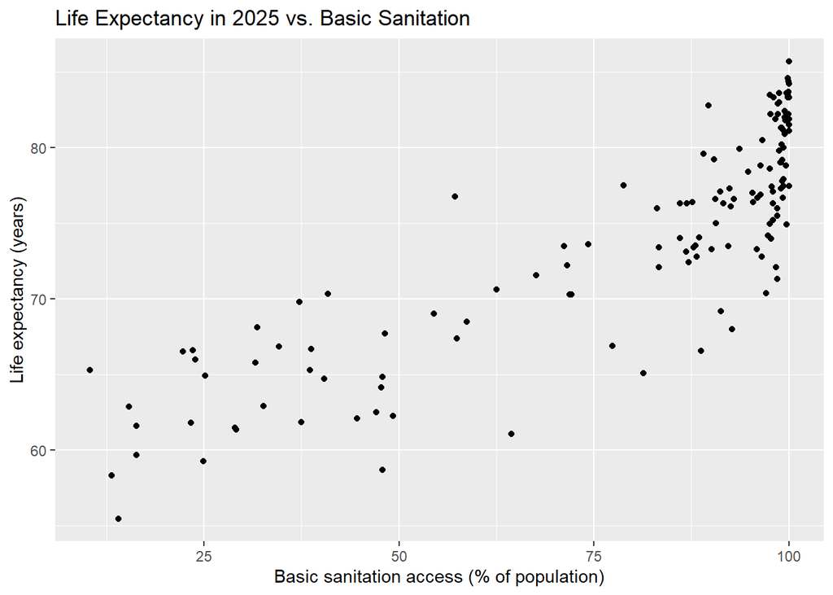

```r
FullData_2025 |>
  ggplot(aes(x = Sanitation, y = LifeExp)) +
  geom_point() +
  labs(x = "Basic sanitation access (% of population)",
       y = "Life expectancy (years)",
       title = "Life Expectancy in 2025 vs. Basic Sanitation")
```

Countries with more access to basic sanitation tend to have higher life expectancy. The pattern is positive and roughly straight. Many countries bunch near 100 percent, and their life expectancy varies a lot, from about 70 to 85 years. Countries with low sanitation are fewer and have lower life expectancy, mostly 55 to 70 years.

### Stats and description

```r
Sanitation_summary <- FullData_2025 |>
  summarize(avg_san = mean(Sanitation),
            sd_san = sd(Sanitation),
            min_san = min(Sanitation),
            max_san = max(Sanitation),
            mdn_san = median(Sanitation),
            iqr_san = IQR(Sanitation),
            count = n())

Sanitation_summary
```

```
   avg_san   sd_san  min_san max_san  mdn_san  iqr_san count
1 78.53025 27.43213 10.35772     100 92.30943 37.22178   140
```

```r
FullData_2025 |>
  summarize(r = cor(Sanitation, LifeExp),
            r_log = cor(log10(Sanitation), LifeExp))
```

```
          r     r_log
1 0.8525734 0.8015773
```

```r
FullData_2025 |>
  slice_min(Sanitation, n = 3) |>
  select(name, Sanitation, LifeExp)
```

```
                      name Sanitation LifeExp
1                 Ethiopia   10.35772   65.28
2                     Chad   13.14153   58.32
3 Central African Republic   14.03628   55.48
```

Sanitation access ranges from 10.36 to 100 percent across 140 countries. The mean is 78.53 and the median is 92.31, so the data is skewed left. The SD is 27.43 and the IQR is 37.22. The correlation with life expectancy is 0.85, which is a strong positive relationship. The lowest values are in Ethiopia (10.36), Chad (13.14), and Central African Republic (14.04). I will not log this variable, because the correlation is stronger on the original scale (0.85 vs. 0.80).The extreme values for traffic deaths, internet use, sanitation, and the low democracy outliers come mostly from Africa.

## Which variable for logging?

From your exploratory data analysis, which variable will need logged/did you log already ? Why?

Traffic deaths is the variable I will log. The data is skewed right. The mean (18.13) is higher than the median (14.40). A few African countries sit far out, with Congo, Dem. Rep. at 96.30 and Rwanda at 76.42 deaths per 100,000. Logging improves the correlation with life expectancy from -0.78 to -0.83. That means the relationship is closer to a straight line after logging.

## Logging predictor variables and splitting data

Split your data into an 80/20 training testing split after logging any variables that need logged.

```r
library(tidymodels)

# Log the variable that needs it
FullData_2025 <- FullData_2025 |>
  mutate(log_Traffic_Deaths = log10(Traffic_Deaths))

# Split the data 80/20
set.seed(1885)   # use the seed your assignment gives you
data_split <- initial_split(FullData_2025, prop = 0.80)

train_data <- training(data_split)
test_data  <- testing(data_split)
nrow(train_data)
```

```
[1] 112
```

```r
nrow(test_data)
```

```
[1] 28
```

```r
# Create list of only predictor variables [Helpful for later model recipes]
predictors <- c("Democracy", colnames(FullData_2025)[5:9],colnames(FullData_2025)[11:14])
```

## Lasso regression

### Making model

Make a lasso regression model for your response vs all predictors on the training data.

```r
FullData_folds <- vfold_cv(train_data, v = 10)

lasso_recipe <- recipe(as.formula(
  paste("LifeExp ~",
        paste(predictors, collapse = " + "))), data = train_data) |>
  step_novel(all_nominal_predictors()) |>
  step_dummy(all_nominal_predictors()) |>
  step_zv(all_predictors()) |>
  step_normalize(all_numeric_predictors())

lasso_spec <- linear_reg(
  penalty = tune(),
  mixture = 1 #this is choosing LASSO
) |>
  set_engine("glmnet")

lasso_workflow <- workflow() |>
  add_recipe(lasso_recipe) |>
  add_model(lasso_spec)

lasso_tuned <- tune_grid(
  lasso_workflow,
  resamples = FullData_folds,
  grid = 50,
  metrics = metric_set(rmse, rsq, mae)
)
```

### Which variables

By looking at the slopes, which variables should be considered included in the model

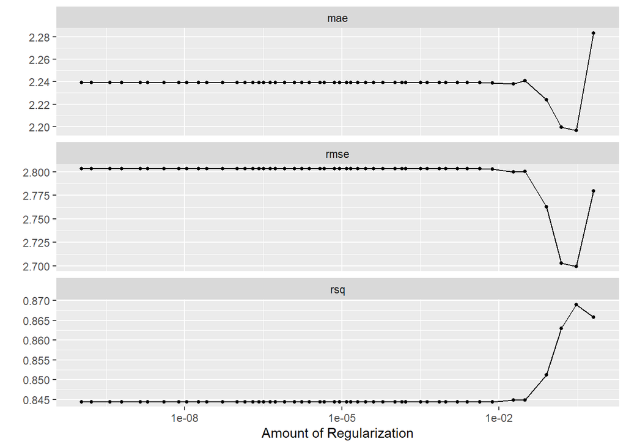

```r
autoplot(lasso_tuned)
```

```r
lasso_best <- select_best(lasso_tuned, metric = "rmse")
lasso_best
```

```
# A tibble: 1 × 2
  penalty .config
    <dbl> <chr>
1   0.300 pre0_mod49_post0
```

```r
lasso_final_workflow <- finalize_workflow(lasso_workflow, lasso_best)
lasso_fit <- fit(lasso_final_workflow, data = train_data)
tidy(lasso_fit)
```

```
# A tibble: 12 × 3
   term                   estimate penalty
   <chr>                     <dbl>   <dbl>
 1 (Intercept)              74.0     0.300
 2 CO2                       0       0.300
 3 GDP                       0       0.300
 4 HDI                       2.90    0.300
 5 Poverty                   0       0.300
 6 Internet                  0       0.300
 7 Sanitation                1.65    0.300
 8 log_Traffic_Deaths       -2.07    0.300
 9 Democracy_Yes             0.105   0.300
10 world_4region_americas    0.331   0.300
11 world_4region_asia        0.179   0.300
12 world_4region_europe      0       0.300
```

Based on the LASSO regression model, the variables to be considered include: `HDI`, `log_Traffic_Deaths`, and `Sanitation`.

*Note about `HDI`:* The use of HDI as a predictor for the `Life Expectancy` response variable should be approached with caution. Although the Human Development Index is seems to be important to the model according to the above table, there is some overlap with the response variable because one of the measures of HDI accounts for life expectancy. This doesn’t necessarily mean it can’t be used in the model, but we should be aware of the direct relationship of these variables.

### Model evaluation-regression metrics on testing.

```r
regression_metrics <- metric_set(mse, rmse, mae)

lasso_test_results <- predict(lasso_fit, test_data) |>
  bind_cols(test_data |> select(LifeExp)) |>
  regression_metrics(truth = LifeExp, estimate = .pred)
lasso_test_results
```

```
# A tibble: 3 × 3
  .metric .estimator .estimate
  <chr>   <chr>          <dbl>
1 mse     standard        6.46
2 rmse    standard        2.54
3 mae     standard        1.90
```

## Regression Tree

### Making model

Make a regression tree model for your response vs all predictors on the training data.

```r
tree_spec <- decision_tree() |>
  set_mode("regression")|>
  set_engine("rpart", model=TRUE)

tree_workflow <- workflow() |>
  add_recipe(lasso_recipe) |>
  add_model(tree_spec)

LifeExp_tree=tree_workflow |>
  fit(data = train_data)

tree_object=LifeExp_tree |>
  extract_fit_engine()
```

### Which variables

By looking at the tree, which variables should be considered included in the model

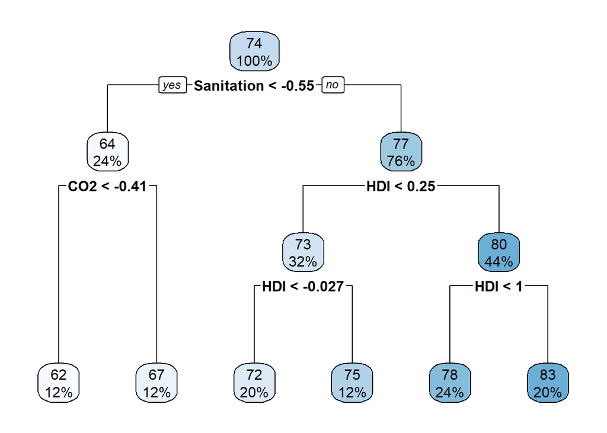

```r
rpart.plot(tree_object)
```

Based on the regression tree, the variables to consider include `Sanitation`, `CO2`, and `HDI`.

*Note about `HDI`:* The use of HDI as a predictor for the `Life Expectancy` response variable should be approached with caution. Although the Human Development Index is seems to be important to the model according to the above graph, there is some overlap with the response variable because one of the measures of HDI accounts for life expectancy. This doesn’t necessarily mean it can’t be used in the model, but we should be aware of the direct relationship of these variables.

### Model evaluation-regression metrics on testing

```r
LifeExp_tree_predict <-
  tree_workflow |>
  fit(data = test_data)

test_results <- augment(LifeExp_tree_predict, new_data = test_data)

test_results|>
  regression_metrics(truth = LifeExp, estimate = .pred)
```

```
# A tibble: 3 × 3
  .metric .estimator .estimate
  <chr>   <chr>          <dbl>
1 mse     standard       14.4
2 rmse    standard        3.79
3 mae     standard        3.16
```

## Random forest

### Making model

Make a random forest model for your response vs all predictors on the training data.

```r
LifExp_recipe=recipe(as.formula(
  paste("LifeExp ~",
        paste(predictors, collapse = " + "))),
  data=train_data) # only count 10 predictor variables

tree_spec <- rand_forest() |>
  set_mode("regression")|>
  set_engine("ranger",importance = "impurity") #Impurity here is sum of squares residual

rf_workflow <- workflow() |>
  add_recipe(LifExp_recipe) |>
  add_model(tree_spec)

LifeExp_rf=rf_workflow |>
  fit(data = train_data)
```

### Which variables

By looking at the variable importance plot, which variables should be considered included in the model

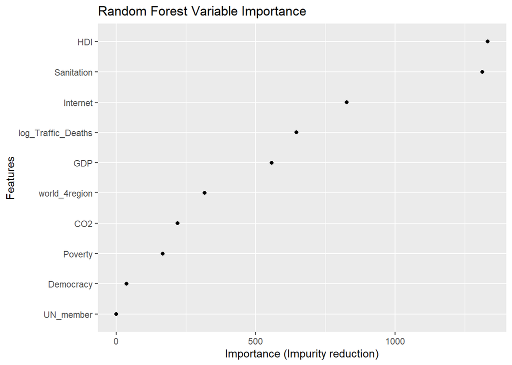

```r
importance_values <- LifeExp_rf |>
  extract_fit_engine() |>
  ranger::importance()

importance_df=importance_values <- tibble(
  Variable = names(importance_values),
  Importance = importance_values
)

importance_df |>
  ggplot(aes(x = reorder(Variable, Importance), y = Importance)) +
  geom_point() +
  coord_flip() +  # Makes variables easy to read vertically
  labs(
    title = "Random Forest Variable Importance",
    x = "Features",
    y = "Importance (Impurity reduction)"
  )
```

From the graph, the main variables that we would consider to include in the model are `HDI` and `Sanitation` since they had the highest importance according to the results of the graph. Other variables that could also be considered are `Internet Users`and `Traffic Deaths` followed by `GDP`.

*Note about `HDI`:* The use of HDI as a predictor for the `Life Expectancy` response variable should be approached with caution. Although the Human Development Index is the best performing variable according to the above graph, there is some overlap with the response variable because one of the measures of HDI accounts for life expectancy. This doesn’t necessarily mean it can’t be used in the model, but we should be aware of the direct relationship of these variables.

### Model evaluation-regression metrics on testing.

```r
regression_metrics <- metric_set(mse, rmse, mae)

LifeExp_rf_predict <-
  rf_workflow |>
  fit(data = test_data)

test_results <- augment(LifeExp_rf_predict, new_data = test_data) ## adding original data


rf_regress_test=test_results|>
  regression_metrics(truth = LifeExp, estimate = .pred)
rf_regress_test
```

```
# A tibble: 3 × 3
  .metric .estimator .estimate
  <chr>   <chr>          <dbl>
1 mse     standard        2.60
2 rmse    standard        1.61
3 mae     standard        1.22
```

## Variable selection comparison

What were the similarities and the difference between the variables selected for each model.

## Best model

Which model would you recommend your team use? Why? Are there trade-offs between interpretability and model metrics?

The recommended model to use would be the Random Forest model. This was chosen as the recommended model because it had the lowest set of evaluation metrics (RMSE, MSE, and MAE) on the test data across all the models created in this document. Random Forest models also tend to generalize to the data better compared to Tree regression models since they average many trees rather than just one reducing risks of potential variance and overfitting.

The trade-off is mainly the issue of interpretability. The result of the variable importance plot only shows which predictors are the best for the model, but it fails to show how much the best predictor variables influence the response Life Expectancy (positive/ negative/ magnitude). Although this trade-off exists, it is still the top choice based on the evaluating metrics on the test set.

## Your question

You will write your own question about the data, create a data visualization that can help answer your question, and write an answer to your question. The question/visualization should explore the relationship between at least 2 of the variables in the dataset. Be sure you include both the question and the answer to your question based on the visualization you have created. It should be a different question than last two mini-projects.

**QUESTION:** What is the relationship between Life Expectancy and a country’s Democratic Status across different Regions?

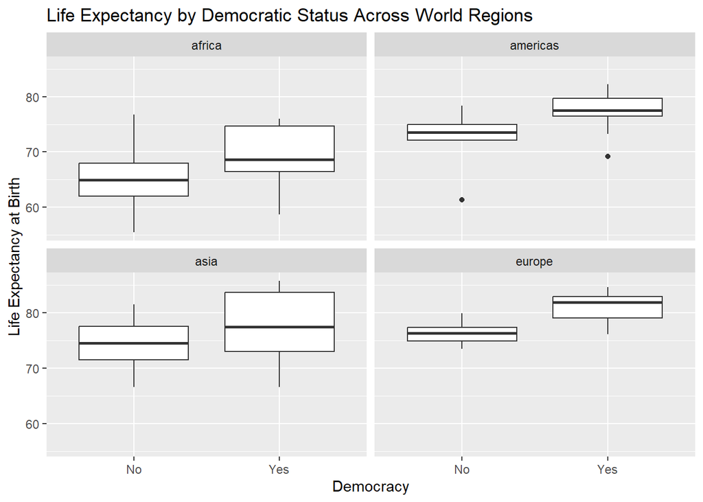

```r
#Side by side boxplots
FullData_2025|>
  ggplot(mapping = aes(x = Democracy, y = LifeExp)) +
  geom_boxplot() +
  facet_wrap(vars(world_4region))+
  labs(title = "Life Expectancy by Democratic Status Across World Regions",
       x = "Democracy",
       y = "Life Expectancy at Birth")
```